# Introduction to fSuSiE

William R.P. Denault

2024-06-19

# fSuSiE

###Model Description

The output of the fitting procedure is a number of “Credible Sets” (CSs), which are each designed to have a high probability of containing a variable with a non-zero effect while at the same time being as small as possible. You can think of the CSs as being a set of “highly correlated” variables that are each associated with the response: you can be confident that one of the variables has a non-zero coefficient, but they are too correlated to be sure which one.

The package is developed by William R.P. Denault from the Stephens Lab at the University of Chicago.

Please post issues to ask questions, get our support, or provide us feedback: please send pull requests if you have helped fix bugs or make improvements to the source code.

### Using fSuSiE

#### the data

The simulated data set is simulated to have exactly two non-zero effects.

Here, we simulate the effects

```r
knitr::opts_chunk$set(
    echo = TRUE,
    message = FALSE,
    warning = FALSE
)
library(fsusieR)
library(susieR)
library(wavethresh)
set.seed(1)
data(N3finemapping)
attach(N3finemapping)
```

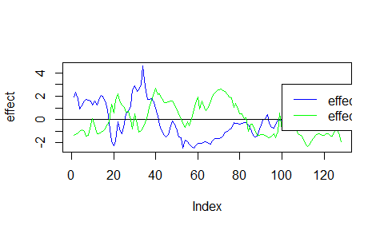

```r
rsnr <- 0.5 #expected root signal noise ratio

pos1 <- 25    #Position of the causal covariate for effect 1
pos2 <- 75    #Position of the causal covariate for effect 2
lev_res <- 7#length of the molecular phenotype (2^lev_res)
f1 <-  simu_IBSS_per_level(lev_res )$sim_func#first effect
f2 <- simu_IBSS_per_level(lev_res )$sim_func #second effect

plot( f1, type ="l", ylab="effect", col="blue")
abline(a=0,b=0)
lines(f2, type="l", col="green")
legend(x=100,
       y=3,
       lty = rep(1,3),
      legend= c("effect 1", "effect 2" ),
       col=c( "blue","green"))
```

So, the underlying causal variants are variant 25 and variant 75. The plot above shows the functional effect of the two variants. Below, we generate the observed curves (effect +noise)

```r
noisy.data  <- list()
X <- N3finemapping$X[,1:100]
for ( i in 1:nrow(X))
{
  f1_obs <- f1
  f2_obs <- f2
  noise <- rnorm(length(f1), sd=  (1/  rsnr ) * var(f1))
  noisy.data [[i]] <-  X[i,pos1]*f1_obs +X[i,pos2]*f2_obs + noise

}
noisy.data <- do.call(rbind, noisy.data)

Y <- noisy.data
```

#### Output and interpretation

Running fSuSiE requires a Y matrix in which each line corresponds to an individual profile/time series. X the genotype matrix in which each line represents the individual genotype and the column the different SNPs. L is an upper bound on the number of causal SNPs within the regions (we advise keeping this parameter below 20).

```r
 out <- susiF(Y,X,L=10)
```

```
#> [1] "Starting initialization"
#> [1] "Data transform"
#> [1] "Discarding  0 wavelet coefficients out of  128"
#> [1] "Data transform done"
#> [1] "Initializing prior"
#> [1] "Initialization done"
#> [1] "Fitting effect  1 , iter 1"
#> [1] "Fitting effect  2 , iter 1"
#> [1] "Fitting effect  3 , iter 1"
#> [1] "Discarding  1  effects"
#> [1] "Fitting effect  1 , iter 2"
#> [1] "Fitting effect  2 , iter 2"
#> [1] "Discarding  8  effects"
#> [1] "Greedy search and backfitting done"
#> [1] "Fitting effect  1 , iter 3"
#> [1] "Fitting effect  2 , iter 3"
#> [1] "Fine mapping done, refining effect estimates using cylce spinning wavelet transform"
```

FSuSiE automatically selects the number of causal effects (here two). The effects detected are summarized in terms of credible sets. Each credible set contains the likely causal covariates for a given effect. You can access them simply as

```r
out$cs
```

```
#> [[1]]
#> [1] 75 83
#>
#> [[2]]
#> [1] 25
```

As you can see, the two CSs contain the correct causal SNPs.

### Visualization

The easiest way to visualize the result is to use the function.

[figure not shown]

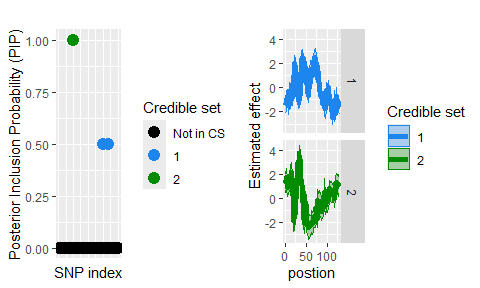

```r
 plot_susiF(out )
```

You can also access the information directly in the output of susiF in the fitted_func part of the output. See below

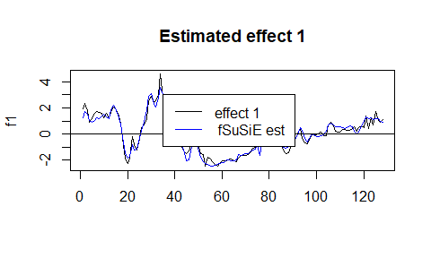

```r
 plot( f1, type="l", main="Estimated effect 1", xlab="")
 lines(get_fitted_effect(out,l=2),col='blue' )
 abline(a=0,b=0)
 legend(x= 35,
        y=3,
        lty= rep(1,2),
        legend = c("effect 1"," fSuSiE est "),
        col=c("black","blue" )
 )
```

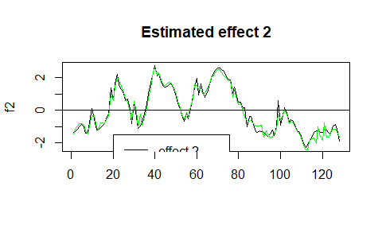

```r
 plot( f2, type="l", main="Estimated effect 2", xlab="")
 lines(get_fitted_effect(out,l=1),col='green' )
 abline(a=0,b=0)
 legend(x= 20,
        y=-1.5,
        lty= rep(1,2),
        legend = c("effect 2"," fSuSiE est "),
        col=c("black","green" )
 )
```

####Posterior inclusion probabilities You can also access the Posterior inclusion probabilities directly from the fitted object. Similarly, you can also specify the plot_susiF function to only display the PiP plot.

```r
out$pip[1:10]
```

```
#>  [1] 0 0 0 0 0 0 0 0 0 0
```

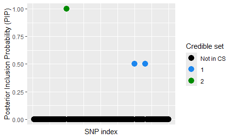

```r
plot_susiF(out, pip_only=TRUE)
```

#### Extracting the regions affected by the credible sets

We provide a build-in function to retrieve the regions where the credible bands are “crossing zero”/i.e., the effects are likely not to be 0 in this region.

```r
 affected_reg( out)
```

```
#>    CS Start End
#> 1   1     1   8
#> 2   1    12  16
#> 8   1    19  19
#> 9   1    21  26
#> 3   1    32  32
#> 4   1    34  34
#> 10  1    38  50
#> 11  1    59  78
#> 5   1    86  98
#> 6   1   104 120
#> 7   1   122 128
#> 17  2     1  16
#> 12  2    19  21
#> 13  2    23  24
#> 18  2    28  39
#> 14  2    44  47
#> 15  2    50  76
#> 16  2    86  90
#> 19  2   106 107
#> 20  2   120 128
```

### Prediction

You can also check the predictive power of susiF by checking the fitted from the output susiF

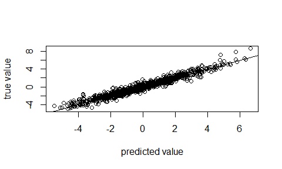

```r
true_sig  <- matrix( X[ ,pos1], ncol=1)%*%t(f1_obs) +matrix( X[ ,pos2], ncol=1)%*%t(f2_obs)


plot(out$ind_fitted_func,  true_sig,
     xlab= "predicted value", ylab="true value")
abline(a=0,b=1)
```

Note that these predictions can differ substantially from the observed noisy curves

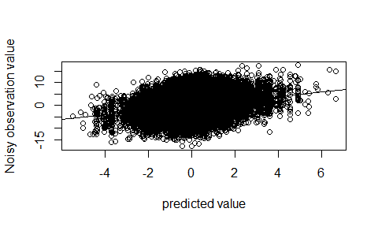

```r
plot(out$ind_fitted_func,  Y,
     xlab= "predicted value", ylab="Noisy observation value")
abline(a=0,b=1)
```

#### Handling function of any length and unevenly space data

Wavelets are primarily designed to analyze functions sampled on $2^J$ evenly spaced positions. However, this assumption is unrealistic in practice. For handling functions of any length, we use the approach of Kovac and Silvermann (2005), which basically remaps the data on a grid of length $2^J$.  
* if you don’t provide the sampling position (e.g., base pair measurement) in the pos argument, susiF considers that the columns of Y correspond to evenly spaced sampling positions. For example, when fine-mapping DNA methylation (DNAm) data, if you are trying to fine-map meQTL, the columns of the Y matrix correspond to different CpG . You provide the genomic position of each of these CpG as a vector in the “pos” argument in the susiF function.

- susiF provides the estimated effect on the remapped effect on a $2^J$ grid.

Example of how to analyze unevenly spaced data. The black lines corresponds to one of the SNP effect in our data, the red ticks corresponds to the sampling positions and the red dots correspond to what part of the effect we can observe.

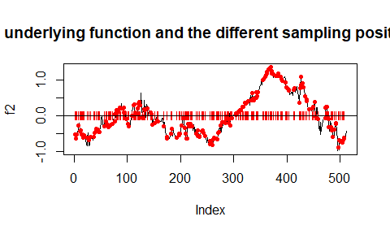

Let’s generate the data under these conditions

```r
  f1_obs <- f1[sampling_pos]
  f2_obs <- f2[sampling_pos]
noisy.data  <- list()
X <- N3finemapping$X[,1:100]
for ( i in 1:nrow(X))
{

  noise <- rnorm(length(f1_obs ), sd=  2)
  noisy.data [[i]] <-  X[i,pos1]*f1_obs +X[i,pos2]*f2_obs + noise

}
noisy.data <- do.call(rbind, noisy.data)

Y <- noisy.data
```

To account for it, pass the sampling position in the pos argument.

```r
 out <- susiF(Y,X,L=3 ,pos= sampling_pos)
```

```
#> [1] "Starting initialization"
#> [1] "Data transform"
#> [1] "Discarding  0 wavelet coefficients out of  256"
#> [1] "Data transform done"
#> [1] "Initializing prior"
#> [1] "Initialization done"
#> [1] "Fitting effect  1 , iter 1"
#> [1] "Fitting effect  2 , iter 1"
#> [1] "Fitting effect  3 , iter 1"
#> [1] "Discarding  1  effects"
#> [1] "Fitting effect  1 , iter 2"
#> [1] "Fitting effect  2 , iter 2"
#> [1] "Discarding  1  effects"
#> [1] "Greedy search and backfitting done"
#> [1] "Fitting effect  1 , iter 3"
#> [1] "Fitting effect  2 , iter 3"
#> [1] "Fine mapping done, refining effect estimates using cylce spinning wavelet transform"
```

To visualize the estimated effect with the correct x coordinate, use the “$outing_grid” object from the susiF.obj

In this example, effect 2 (in our simulation) is captured in the first CS. The black line is the actual true effect. The red dots are the effect level at the sampling position, the thick blue line is the estimated effect, and the dashed line is the 95% credible bands.

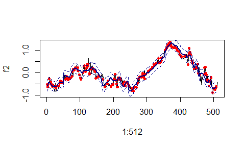

```r
plot(   x=1:512,           y=f2,type="l")
points( x=sampling_pos,    y=f2_obs, col="red",pch=20)
lines(  x=out$outing_grid, y=out$fitted_func[[1]]    ,col='darkblue', lwd=2)
lines(  x=out$outing_grid, y= out$cred_band[[1]][1,] ,col='darkblue',lty=2 )
lines(  x=out$outing_grid, y= out$cred_band[[1]][2,] ,col='darkblue' ,lty=2 )
```

#### A note on the priors available

Here is a comparison between their running time

```r
 out1 <- susiF(Y,X,L=3 , prior = 'mixture_normal_per_scale',verbose=FALSE)
```

```
#> [1] "Fine mapping done, refining effect estimates using cylce spinning wavelet transform"
```

```r
 out1$runtime
```

```
#>    user  system elapsed
#>    8.31    0.27   12.08
```

```r
 out2 <- susiF(Y,X,L=3 , prior = 'mixture_normal',verbose=FALSE)
```

```
#> [1] "Fine mapping done, refining effect estimates using cylce spinning wavelet transform"
```

```r
 out2$runtime
```

```
#>    user  system elapsed
#>    3.05    0.09    4.17
```

[^1]: this vignette is based on the original SuSiE vignette by [Gao Wang](https://stephenslab.github.io/susieR/articles/finemapping.html)